# Feature Engineering Real Estate Analytics Project

```python
# import all needed libraries

import numpy as np
import matplotlib.pyplot as plt
%matplotlib inline
import pandas as pd
import seaborn as sns
```

```python
# Put the data set's data into a DataFrame.

df = pd.read_csv("Feature Engineering Dataset\Feature_Engineering_Dataset\PEP1.csv")
```

```python
# Print the whole data set
df
```

|  | Id | MSSubClass | MSZoning | LotFrontage | LotArea | Street | Alley | LotShape | LandContour | Utilities | ... | PoolArea | PoolQC | Fence | MiscFeature | MiscVal | MoSold | YrSold | SaleType | SaleCondition | SalePrice |
| --- | --- | --- | --- | --- | --- | --- | --- | --- | --- | --- | --- | --- | --- | --- | --- | --- | --- | --- | --- | --- | --- |
| 0 | 1 | 60 | RL | 65.0 | 8450 | Pave | NaN | Reg | Lvl | AllPub | ... | 0 | NaN | NaN | NaN | 0 | 2 | 2008 | WD | Normal | 208500 |
| 1 | 2 | 20 | RL | 80.0 | 9600 | Pave | NaN | Reg | Lvl | AllPub | ... | 0 | NaN | NaN | NaN | 0 | 5 | 2007 | WD | Normal | 181500 |
| 2 | 3 | 60 | RL | 68.0 | 11250 | Pave | NaN | IR1 | Lvl | AllPub | ... | 0 | NaN | NaN | NaN | 0 | 9 | 2008 | WD | Normal | 223500 |
| 3 | 4 | 70 | RL | 60.0 | 9550 | Pave | NaN | IR1 | Lvl | AllPub | ... | 0 | NaN | NaN | NaN | 0 | 2 | 2006 | WD | Abnorml | 140000 |
| 4 | 5 | 60 | RL | 84.0 | 14260 | Pave | NaN | IR1 | Lvl | AllPub | ... | 0 | NaN | NaN | NaN | 0 | 12 | 2008 | WD | Normal | 250000 |
| ... | ... | ... | ... | ... | ... | ... | ... | ... | ... | ... | ... | ... | ... | ... | ... | ... | ... | ... | ... | ... | ... |
| 1455 | 1456 | 60 | RL | 62.0 | 7917 | Pave | NaN | Reg | Lvl | AllPub | ... | 0 | NaN | NaN | NaN | 0 | 8 | 2007 | WD | Normal | 175000 |
| 1456 | 1457 | 20 | RL | 85.0 | 13175 | Pave | NaN | Reg | Lvl | AllPub | ... | 0 | NaN | MnPrv | NaN | 0 | 2 | 2010 | WD | Normal | 210000 |
| 1457 | 1458 | 70 | RL | 66.0 | 9042 | Pave | NaN | Reg | Lvl | AllPub | ... | 0 | NaN | GdPrv | Shed | 2500 | 5 | 2010 | WD | Normal | 266500 |
| 1458 | 1459 | 20 | RL | 68.0 | 9717 | Pave | NaN | Reg | Lvl | AllPub | ... | 0 | NaN | NaN | NaN | 0 | 4 | 2010 | WD | Normal | 142125 |
| 1459 | 1460 | 20 | RL | 75.0 | 9937 | Pave | NaN | Reg | Lvl | AllPub | ... | 0 | NaN | NaN | NaN | 0 | 6 | 2008 | WD | Normal | 147500 |

1460 rows × 81 columns

```python
# Print the head of the data set
df.head()
```

|  | Id | MSSubClass | MSZoning | LotFrontage | LotArea | Street | Alley | LotShape | LandContour | Utilities | ... | PoolArea | PoolQC | Fence | MiscFeature | MiscVal | MoSold | YrSold | SaleType | SaleCondition | SalePrice |
| --- | --- | --- | --- | --- | --- | --- | --- | --- | --- | --- | --- | --- | --- | --- | --- | --- | --- | --- | --- | --- | --- |
| 0 | 1 | 60 | RL | 65.0 | 8450 | Pave | NaN | Reg | Lvl | AllPub | ... | 0 | NaN | NaN | NaN | 0 | 2 | 2008 | WD | Normal | 208500 |
| 1 | 2 | 20 | RL | 80.0 | 9600 | Pave | NaN | Reg | Lvl | AllPub | ... | 0 | NaN | NaN | NaN | 0 | 5 | 2007 | WD | Normal | 181500 |
| 2 | 3 | 60 | RL | 68.0 | 11250 | Pave | NaN | IR1 | Lvl | AllPub | ... | 0 | NaN | NaN | NaN | 0 | 9 | 2008 | WD | Normal | 223500 |
| 3 | 4 | 70 | RL | 60.0 | 9550 | Pave | NaN | IR1 | Lvl | AllPub | ... | 0 | NaN | NaN | NaN | 0 | 2 | 2006 | WD | Abnorml | 140000 |
| 4 | 5 | 60 | RL | 84.0 | 14260 | Pave | NaN | IR1 | Lvl | AllPub | ... | 0 | NaN | NaN | NaN | 0 | 12 | 2008 | WD | Normal | 250000 |

5 rows × 81 columns

```python
# Print all the column names
df.columns
```

```
Index(['Id', 'MSSubClass', 'MSZoning', 'LotFrontage', 'LotArea', 'Street',
       'Alley', 'LotShape', 'LandContour', 'Utilities', 'LotConfig',
       'LandSlope', 'Neighborhood', 'Condition1', 'Condition2', 'BldgType',
       'HouseStyle', 'OverallQual', 'OverallCond', 'YearBuilt', 'YearRemodAdd',
       'RoofStyle', 'RoofMatl', 'Exterior1st', 'Exterior2nd', 'MasVnrType',
       'MasVnrArea', 'ExterQual', 'ExterCond', 'Foundation', 'BsmtQual',
       'BsmtCond', 'BsmtExposure', 'BsmtFinType1', 'BsmtFinSF1',
       'BsmtFinType2', 'BsmtFinSF2', 'BsmtUnfSF', 'TotalBsmtSF', 'Heating',
       'HeatingQC', 'CentralAir', 'Electrical', '1stFlrSF', '2ndFlrSF',
       'LowQualFinSF', 'GrLivArea', 'BsmtFullBath', 'BsmtHalfBath', 'FullBath',
       'HalfBath', 'BedroomAbvGr', 'KitchebvGr', 'KitchenQual', 'TotRmsAbvGrd',
       'Functiol', 'Fireplaces', 'FireplaceQu', 'GarageType', 'GarageYrBlt',
       'GarageFinish', 'GarageCars', 'GarageArea', 'GarageQual', 'GarageCond',
       'PavedDrive', 'WoodDeckSF', 'OpenPorchSF', 'EnclosedPorch', '3SsnPorch',
       'ScreenPorch', 'PoolArea', 'PoolQC', 'Fence', 'MiscFeature', 'MiscVal',
       'MoSold', 'YrSold', 'SaleType', 'SaleCondition', 'SalePrice'],
      dtype='object')
```

```python
# Print the shape of the data set in a (row, column) tuple.
df.shape
```

```
(1460, 81)
```

```python
# Get the information about the entire DataFrame.
df.info()
```

```
<class 'pandas.core.frame.DataFrame'>
RangeIndex: 1460 entries, 0 to 1459
Data columns (total 81 columns):
 #   Column         Non-Null Count  Dtype
---  ------         --------------  -----
 0   Id             1460 non-null   int64
 1   MSSubClass     1460 non-null   int64
 2   MSZoning       1460 non-null   object
 3   LotFrontage    1201 non-null   float64
 4   LotArea        1460 non-null   int64
 5   Street         1460 non-null   object
 6   Alley          91 non-null     object
 7   LotShape       1460 non-null   object
 8   LandContour    1460 non-null   object
 9   Utilities      1460 non-null   object
```

[output cut: 73 more lines]

```python
# Check if there are missing values in the data set
df.isna().any()
```

```
Id               False
MSSubClass       False
MSZoning         False
LotFrontage       True
LotArea          False
                 ...
MoSold           False
YrSold           False
SaleType         False
SaleCondition    False
SalePrice        False
Length: 81, dtype: bool
```

```python
# Print all the unique values in the data set by printing the DataFrame in a for loop with separating lines.
# Each column's name is listed followed by an nparray of the unique values.

for i in df.columns:
    print (i , ":", df[i].unique())
    print (" _ "*40)
    print (" _ "*40)
```

```
Id : [   1    2    3 ... 1458 1459 1460]
 _  _  _  _  _  _  _  _  _  _  _  _  _  _  _  _  _  _  _  _  _  _  _  _  _  _  _  _  _  _  _  _  _  _  _  _  _  _  _  _
 _  _  _  _  _  _  _  _  _  _  _  _  _  _  _  _  _  _  _  _  _  _  _  _  _  _  _  _  _  _  _  _  _  _  _  _  _  _  _  _
MSSubClass : [ 60  20  70  50 190  45  90 120  30  85  80 160  75 180  40]
 _  _  _  _  _  _  _  _  _  _  _  _  _  _  _  _  _  _  _  _  _  _  _  _  _  _  _  _  _  _  _  _  _  _  _  _  _  _  _  _
 _  _  _  _  _  _  _  _  _  _  _  _  _  _  _  _  _  _  _  _  _  _  _  _  _  _  _  _  _  _  _  _  _  _  _  _  _  _  _  _
MSZoning : ['RL' 'RM' 'C (all)' 'FV' 'RH']
 _  _  _  _  _  _  _  _  _  _  _  _  _  _  _  _  _  _  _  _  _  _  _  _  _  _  _  _  _  _  _  _  _  _  _  _  _  _  _  _
 _  _  _  _  _  _  _  _  _  _  _  _  _  _  _  _  _  _  _  _  _  _  _  _  _  _  _  _  _  _  _  _  _  _  _  _  _  _  _  _
LotFrontage : [ 65.  80.  68.  60.  84.  85.  75.  nan  51.  50.  70.  91.  72.  66.
 101.  57.  44. 110.  98.  47. 108. 112.  74. 115.  61.  48.  33.  52.
 100.  24.  89.  63.  76.  81.  95.  69.  21.  32.  78. 121. 122.  40.
 105.  73.  77.  64.  94.  34.  90.  55.  88.  82.  71. 120. 107.  92.
 134.  62.  86. 141.  97.  54.  41.  79. 174.  99.  67.  83.  43. 103.
  93.  30. 129. 140.  35.  37. 118.  87. 116. 150. 111.  49.  96.  59.
  36.  56. 102.  58.  38. 109. 130.  53. 137.  45. 106. 104.  42.  39.
 144. 114. 128. 149. 313. 168. 182. 138. 160. 152. 124. 153.  46.]
 _  _  _  _  _  _  _  _  _  _  _  _  _  _  _  _  _  _  _  _  _  _  _  _  _  _  _  _  _  _  _  _  _  _  _  _  _  _  _  _
 _  _  _  _  _  _  _  _  _  _  _  _  _  _  _  _  _  _  _  _  _  _  _  _  _  _  _  _  _  _  _  _  _  _  _  _  _  _  _  _
LotArea : [ 8450  9600 11250 ... 17217 13175  9717]
 _  _  _  _  _  _  _  _  _  _  _  _  _  _  _  _  _  _  _  _  _  _  _  _  _  _  _  _  _  _  _  _  _  _  _  _  _  _  _  _
 _  _  _  _  _  _  _  _  _  _  _  _  _  _  _  _  _  _  _  _  _  _  _  _  _  _  _  _  _  _  _  _  _  _  _  _  _  _  _  _
Street : ['Pave' 'Grvl']
 _  _  _  _  _  _  _  _  _  _  _  _  _  _  _  _  _  _  _  _  _  _  _  _  _  _  _  _  _  _  _  _  _  _  _  _  _  _  _  _
 _  _  _  _  _  _  _  _  _  _  _  _  _  _  _  _  _  _  _  _  _  _  _  _  _  _  _  _  _  _  _  _  _  _  _  _  _  _  _  _
Alley : [nan 'Grvl' 'Pave']
 _  _  _  _  _  _  _  _  _  _  _  _  _  _  _  _  _  _  _  _  _  _  _  _  _  _  _  _  _  _  _  _  _  _  _  _  _  _  _  _
 _  _  _  _  _  _  _  _  _  _  _  _  _  _  _  _  _  _  _  _  _  _  _  _  _  _  _  _  _  _  _  _  _  _  _  _  _  _  _  _
LotShape : ['Reg' 'IR1' 'IR2' 'IR3']
 _  _  _  _  _  _  _  _  _  _  _  _  _  _  _  _  _  _  _  _  _  _  _  _  _  _  _  _  _  _  _  _  _  _  _  _  _  _  _  _
 _  _  _  _  _  _  _  _  _  _  _  _  _  _  _  _  _  _  _  _  _  _  _  _  _  _  _  _  _  _  _  _  _  _  _  _  _  _  _  _
LandContour : ['Lvl' 'Bnk' 'Low' 'HLS']
 _  _  _  _  _  _  _  _  _  _  _  _  _  _  _  _  _  _  _  _  _  _  _  _  _  _  _  _  _  _  _  _  _  _  _  _  _  _  _  _
 _  _  _  _  _  _  _  _  _  _  _  _  _  _  _  _  _  _  _  _  _  _  _  _  _  _  _  _  _  _  _  _  _  _  _  _  _  _  _  _
Utilities : ['AllPub' 'NoSeWa']
 _  _  _  _  _  _  _  _  _  _  _  _  _  _  _  _  _  _  _  _  _  _  _  _  _  _  _  _  _  _  _  _  _  _  _  _  _  _  _  _
 _  _  _  _  _  _  _  _  _  _  _  _  _  _  _  _  _  _  _  _  _  _  _  _  _  _  _  _  _  _  _  _  _  _  _  _  _  _  _  _
LotConfig : ['Inside' 'FR2' 'Corner' 'CulDSac' 'FR3']
 _  _  _  _  _  _  _  _  _  _  _  _  _  _  _  _  _  _  _  _  _  _  _  _  _  _  _  _  _  _  _  _  _  _  _  _  _  _  _  _
 _  _  _  _  _  _  _  _  _  _  _  _  _  _  _  _  _  _  _  _  _  _  _  _  _  _  _  _  _  _  _  _  _  _  _  _  _  _  _  _
```

[output cut: 708 more lines]

```
 227000 203000 213490 194000 287000 293077 310000 119750  84000 315500
 262280 278000 139600 556581  84900 176485 200141 185850 328000 167900
 151400  91500 138800 155900  83500 252000  92900 176432 274725 134500
 184100 133700 118400 212900 163900 259000 239500  94000 424870 174500
 116900 201800 218000 235128 108959 233170 245350 625000 171900 154900
 392500 745000 186700 104900 262000 219210 116050 271900 229456  80500
 137900 367294 101800 138887 265900 248328 465000 186500 169900 171750
 294000 165400 301500  99900 128900 183900 378500 381000 185750  68400
 150500 281000 333168 206900 295493 111000 156500  72500  52500 155835
 108500 283463 410000 156932 144152 216000 274300 466500  58500 237500
 377500 246578 281213 137450 193879 282922 257000 223000 274970 182900
 192140 143750  64500 394617 149700 149300 121000 179600  92000 287090
 266500 142125 147500]
 _  _  _  _  _  _  _  _  _  _  _  _  _  _  _  _  _  _  _  _  _  _  _  _  _  _  _  _  _  _  _  _  _  _  _  _  _  _  _  _
 _  _  _  _  _  _  _  _  _  _  _  _  _  _  _  _  _  _  _  _  _  _  _  _  _  _  _  _  _  _  _  _  _  _  _  _  _  _  _  _
```

```python
# Print the uniques values in just one column to see what the output looks like
df['LotFrontage'].unique()
```

```
array([ 65.,  80.,  68.,  60.,  84.,  85.,  75.,  nan,  51.,  50.,  70.,
        91.,  72.,  66., 101.,  57.,  44., 110.,  98.,  47., 108., 112.,
        74., 115.,  61.,  48.,  33.,  52., 100.,  24.,  89.,  63.,  76.,
        81.,  95.,  69.,  21.,  32.,  78., 121., 122.,  40., 105.,  73.,
        77.,  64.,  94.,  34.,  90.,  55.,  88.,  82.,  71., 120., 107.,
        92., 134.,  62.,  86., 141.,  97.,  54.,  41.,  79., 174.,  99.,
        67.,  83.,  43., 103.,  93.,  30., 129., 140.,  35.,  37., 118.,
        87., 116., 150., 111.,  49.,  96.,  59.,  36.,  56., 102.,  58.,
        38., 109., 130.,  53., 137.,  45., 106., 104.,  42.,  39., 144.,
       114., 128., 149., 313., 168., 182., 138., 160., 152., 124., 153.,
        46.])
```

## Separate into numerical and categorical data

```python
# Select numeric and categorical data by putting the data into two new DataFrames for each type.
numericDF = df.select_dtypes(include=[np.number])
categoricDF = df.select_dtypes(exclude=[np.number])
```

```python
# Print the numerical and categorical data column names as two lists.

numericCol = numericDF.columns.tolist()
categoryCol = categoricDF.columns.tolist()
print ("Categorical data column names:", categoryCol)
print ("\n Numerical data column names:", numericCol)
```

```
Categorical data column names: ['MSZoning', 'Street', 'Alley', 'LotShape', 'LandContour', 'Utilities', 'LotConfig', 'LandSlope', 'Neighborhood', 'Condition1', 'Condition2', 'BldgType', 'HouseStyle', 'RoofStyle', 'RoofMatl', 'Exterior1st', 'Exterior2nd', 'MasVnrType', 'ExterQual', 'ExterCond', 'Found…

 Numerical data column names: ['Id', 'MSSubClass', 'LotFrontage', 'LotArea', 'OverallQual', 'OverallCond', 'YearBuilt', 'YearRemodAdd', 'MasVnrArea', 'BsmtFinSF1', 'BsmtFinSF2', 'BsmtUnfSF', 'TotalBsmtSF', '1stFlrSF', '2ndFlrSF', 'LowQualFinSF', 'GrLivArea', 'BsmtFullBath', 'BsmtHalfBath', 'FullBath…
```

```python
# Print the head of the numerical DataFrame
numericDF.head()
```

|  | Id | MSSubClass | LotFrontage | LotArea | OverallQual | OverallCond | YearBuilt | YearRemodAdd | MasVnrArea | BsmtFinSF1 | ... | WoodDeckSF | OpenPorchSF | EnclosedPorch | 3SsnPorch | ScreenPorch | PoolArea | MiscVal | MoSold | YrSold | SalePrice |
| --- | --- | --- | --- | --- | --- | --- | --- | --- | --- | --- | --- | --- | --- | --- | --- | --- | --- | --- | --- | --- | --- |
| 0 | 1 | 60 | 65.0 | 8450 | 7 | 5 | 2003 | 2003 | 196.0 | 706 | ... | 0 | 61 | 0 | 0 | 0 | 0 | 0 | 2 | 2008 | 208500 |
| 1 | 2 | 20 | 80.0 | 9600 | 6 | 8 | 1976 | 1976 | 0.0 | 978 | ... | 298 | 0 | 0 | 0 | 0 | 0 | 0 | 5 | 2007 | 181500 |
| 2 | 3 | 60 | 68.0 | 11250 | 7 | 5 | 2001 | 2002 | 162.0 | 486 | ... | 0 | 42 | 0 | 0 | 0 | 0 | 0 | 9 | 2008 | 223500 |
| 3 | 4 | 70 | 60.0 | 9550 | 7 | 5 | 1915 | 1970 | 0.0 | 216 | ... | 0 | 35 | 272 | 0 | 0 | 0 | 0 | 2 | 2006 | 140000 |
| 4 | 5 | 60 | 84.0 | 14260 | 8 | 5 | 2000 | 2000 | 350.0 | 655 | ... | 192 | 84 | 0 | 0 | 0 | 0 | 0 | 12 | 2008 | 250000 |

5 rows × 38 columns

```python
# Print the head of the categorical DataFrame
categoricDF.head()
```

|  | MSZoning | Street | Alley | LotShape | LandContour | Utilities | LotConfig | LandSlope | Neighborhood | Condition1 | ... | GarageType | GarageFinish | GarageQual | GarageCond | PavedDrive | PoolQC | Fence | MiscFeature | SaleType | SaleCondition |
| --- | --- | --- | --- | --- | --- | --- | --- | --- | --- | --- | --- | --- | --- | --- | --- | --- | --- | --- | --- | --- | --- |
| 0 | RL | Pave | NaN | Reg | Lvl | AllPub | Inside | Gtl | CollgCr | Norm | ... | Attchd | RFn | TA | TA | Y | NaN | NaN | NaN | WD | Normal |
| 1 | RL | Pave | NaN | Reg | Lvl | AllPub | FR2 | Gtl | Veenker | Feedr | ... | Attchd | RFn | TA | TA | Y | NaN | NaN | NaN | WD | Normal |
| 2 | RL | Pave | NaN | IR1 | Lvl | AllPub | Inside | Gtl | CollgCr | Norm | ... | Attchd | RFn | TA | TA | Y | NaN | NaN | NaN | WD | Normal |
| 3 | RL | Pave | NaN | IR1 | Lvl | AllPub | Corner | Gtl | Crawfor | Norm | ... | Detchd | Unf | TA | TA | Y | NaN | NaN | NaN | WD | Abnorml |
| 4 | RL | Pave | NaN | IR1 | Lvl | AllPub | FR2 | Gtl | NoRidge | Norm | ... | Attchd | RFn | TA | TA | Y | NaN | NaN | NaN | WD | Normal |

5 rows × 43 columns

## Descriptive Stats and EDA

### Missing values in numericDF: Our next step is to deal with the missing values in the numerical data set. If there are missing values in the DataFrame, we must fill the missing values using an imputer.

```python
# Import the simple imputer package from scikit-learn
from sklearn.impute import SimpleImputer
```

```python
# Check for missing values in the DF. Here, "True" indicates missing values and "False" indicates no missing values.
numericDF.isna().any()
```

```
Id               False
MSSubClass       False
LotFrontage       True
LotArea          False
OverallQual      False
OverallCond      False
YearBuilt        False
YearRemodAdd     False
MasVnrArea        True
BsmtFinSF1       False
BsmtFinSF2       False
BsmtUnfSF        False
TotalBsmtSF      False
1stFlrSF         False
2ndFlrSF         False
LowQualFinSF     False
GrLivArea        False
BsmtFullBath     False
BsmtHalfBath     False
FullBath         False
HalfBath         False
BedroomAbvGr     False
KitchebvGr       False
TotRmsAbvGrd     False
Fireplaces       False
GarageYrBlt       True
GarageCars       False
GarageArea       False
WoodDeckSF       False
OpenPorchSF      False
EnclosedPorch    False
3SsnPorch        False
ScreenPorch      False
PoolArea         False
MiscVal          False
MoSold           False
YrSold           False
SalePrice        False
dtype: bool
```

```python
# Some of the values are missing from the LotFrontage, MasVnrArea, and GarageYrBlt columns.

# We can fill the missing values with either the mean or median in each column. Let's make an imputer for each variation.

# Make the mean imputer
meanImputer = SimpleImputer(missing_values = np.nan, strategy = "mean")
meanImputer = meanImputer.fit(numericDF)

# Make the median imputer
medianImputer = SimpleImputer(missing_values = np.nan, strategy = "median")
medianImputer = medianImputer.fit(numericDF)
```

```python
# Use the mean imputer to make an new DataFrame that fills the missing values with the mean of each column

meanImputedNumDFArr = meanImputer.transform(numericDF)                                      # Make a np array that contains the imputed values
meanImputedNumDF = pd.DataFrame(data = meanImputedNumDFArr, columns = numericDF.columns)    # Make a DF using the np array's data

meanImputedNumDF.head()
```

|  | Id | MSSubClass | LotFrontage | LotArea | OverallQual | OverallCond | YearBuilt | YearRemodAdd | MasVnrArea | BsmtFinSF1 | ... | WoodDeckSF | OpenPorchSF | EnclosedPorch | 3SsnPorch | ScreenPorch | PoolArea | MiscVal | MoSold | YrSold | SalePrice |
| --- | --- | --- | --- | --- | --- | --- | --- | --- | --- | --- | --- | --- | --- | --- | --- | --- | --- | --- | --- | --- | --- |
| 0 | 1.0 | 60.0 | 65.0 | 8450.0 | 7.0 | 5.0 | 2003.0 | 2003.0 | 196.0 | 706.0 | ... | 0.0 | 61.0 | 0.0 | 0.0 | 0.0 | 0.0 | 0.0 | 2.0 | 2008.0 | 208500.0 |
| 1 | 2.0 | 20.0 | 80.0 | 9600.0 | 6.0 | 8.0 | 1976.0 | 1976.0 | 0.0 | 978.0 | ... | 298.0 | 0.0 | 0.0 | 0.0 | 0.0 | 0.0 | 0.0 | 5.0 | 2007.0 | 181500.0 |
| 2 | 3.0 | 60.0 | 68.0 | 11250.0 | 7.0 | 5.0 | 2001.0 | 2002.0 | 162.0 | 486.0 | ... | 0.0 | 42.0 | 0.0 | 0.0 | 0.0 | 0.0 | 0.0 | 9.0 | 2008.0 | 223500.0 |
| 3 | 4.0 | 70.0 | 60.0 | 9550.0 | 7.0 | 5.0 | 1915.0 | 1970.0 | 0.0 | 216.0 | ... | 0.0 | 35.0 | 272.0 | 0.0 | 0.0 | 0.0 | 0.0 | 2.0 | 2006.0 | 140000.0 |
| 4 | 5.0 | 60.0 | 84.0 | 14260.0 | 8.0 | 5.0 | 2000.0 | 2000.0 | 350.0 | 655.0 | ... | 192.0 | 84.0 | 0.0 | 0.0 | 0.0 | 0.0 | 0.0 | 12.0 | 2008.0 | 250000.0 |

5 rows × 38 columns

```python
# Use the median imputer to make an new DataFrame that fills the missing values with the median of each column

medianImputedNumDFArr = medianImputer.transform(numericDF)                                      # Make a np array that contains the imputed values
medianImputedNumDF = pd.DataFrame(data = medianImputedNumDFArr, columns = numericDF.columns)    # Make a DF using the np array's data

medianImputedNumDF.head()
```

|  | Id | MSSubClass | LotFrontage | LotArea | OverallQual | OverallCond | YearBuilt | YearRemodAdd | MasVnrArea | BsmtFinSF1 | ... | WoodDeckSF | OpenPorchSF | EnclosedPorch | 3SsnPorch | ScreenPorch | PoolArea | MiscVal | MoSold | YrSold | SalePrice |
| --- | --- | --- | --- | --- | --- | --- | --- | --- | --- | --- | --- | --- | --- | --- | --- | --- | --- | --- | --- | --- | --- |
| 0 | 1.0 | 60.0 | 65.0 | 8450.0 | 7.0 | 5.0 | 2003.0 | 2003.0 | 196.0 | 706.0 | ... | 0.0 | 61.0 | 0.0 | 0.0 | 0.0 | 0.0 | 0.0 | 2.0 | 2008.0 | 208500.0 |
| 1 | 2.0 | 20.0 | 80.0 | 9600.0 | 6.0 | 8.0 | 1976.0 | 1976.0 | 0.0 | 978.0 | ... | 298.0 | 0.0 | 0.0 | 0.0 | 0.0 | 0.0 | 0.0 | 5.0 | 2007.0 | 181500.0 |
| 2 | 3.0 | 60.0 | 68.0 | 11250.0 | 7.0 | 5.0 | 2001.0 | 2002.0 | 162.0 | 486.0 | ... | 0.0 | 42.0 | 0.0 | 0.0 | 0.0 | 0.0 | 0.0 | 9.0 | 2008.0 | 223500.0 |
| 3 | 4.0 | 70.0 | 60.0 | 9550.0 | 7.0 | 5.0 | 1915.0 | 1970.0 | 0.0 | 216.0 | ... | 0.0 | 35.0 | 272.0 | 0.0 | 0.0 | 0.0 | 0.0 | 2.0 | 2006.0 | 140000.0 |
| 4 | 5.0 | 60.0 | 84.0 | 14260.0 | 8.0 | 5.0 | 2000.0 | 2000.0 | 350.0 | 655.0 | ... | 192.0 | 84.0 | 0.0 | 0.0 | 0.0 | 0.0 | 0.0 | 12.0 | 2008.0 | 250000.0 |

5 rows × 38 columns

```python
# Print out the columns that contained missing values to examine the mean imputation results.
meanImputedNumDF[["LotFrontage", "MasVnrArea", "GarageYrBlt"]]
```

|  | LotFrontage | MasVnrArea | GarageYrBlt |
| --- | --- | --- | --- |
| 0 | 65.0 | 196.0 | 2003.0 |
| 1 | 80.0 | 0.0 | 1976.0 |
| 2 | 68.0 | 162.0 | 2001.0 |
| 3 | 60.0 | 0.0 | 1998.0 |
| 4 | 84.0 | 350.0 | 2000.0 |
| ... | ... | ... | ... |
| 1455 | 62.0 | 0.0 | 1999.0 |
| 1456 | 85.0 | 119.0 | 1978.0 |
| 1457 | 66.0 | 0.0 | 1941.0 |
| 1458 | 68.0 | 0.0 | 1950.0 |
| 1459 | 75.0 | 0.0 | 1965.0 |

1460 rows × 3 columns

```python
# Print out the columns that contained missing values to examine the median imputation results.
medianImputedNumDF[["LotFrontage", "MasVnrArea", "GarageYrBlt"]]
```

|  | LotFrontage | MasVnrArea | GarageYrBlt |
| --- | --- | --- | --- |
| 0 | 65.0 | 196.0 | 2003.0 |
| 1 | 80.0 | 0.0 | 1976.0 |
| 2 | 68.0 | 162.0 | 2001.0 |
| 3 | 60.0 | 0.0 | 1998.0 |
| 4 | 84.0 | 350.0 | 2000.0 |
| ... | ... | ... | ... |
| 1455 | 62.0 | 0.0 | 1999.0 |
| 1456 | 85.0 | 119.0 | 1978.0 |
| 1457 | 66.0 | 0.0 | 1941.0 |
| 1458 | 68.0 | 0.0 | 1950.0 |
| 1459 | 75.0 | 0.0 | 1965.0 |

1460 rows × 3 columns

```python
# Check if missing values exist in the columns of the mean DataFrame.
meanImputedNumDF[["LotFrontage", "MasVnrArea", "GarageYrBlt"]].isna().any()
```

```
LotFrontage    False
MasVnrArea     False
GarageYrBlt    False
dtype: bool
```

```python
#  Check if missing values exist in the columns of the median DataFrame.
medianImputedNumDF[["LotFrontage", "MasVnrArea", "GarageYrBlt"]].isna().any()
```

```
LotFrontage    False
MasVnrArea     False
GarageYrBlt    False
dtype: bool
```

```python
# As a santiy check, test if the original array still has missing values.
numericDF[["LotFrontage", "MasVnrArea", "GarageYrBlt"]].isna().any()
```

```
LotFrontage    True
MasVnrArea     True
GarageYrBlt    True
dtype: bool
```

```python
# Print out a transposed version of the imputed numeric DataFrame to view the columns more easily. Start with the mean imputed DF.

meanNumDFTrans = meanImputedNumDF.T
meanNumDFTrans
```

|  | 0 | 1 | 2 | 3 | 4 | 5 | 6 | 7 | 8 | 9 | ... | 1450 | 1451 | 1452 | 1453 | 1454 | 1455 | 1456 | 1457 | 1458 | 1459 |
| --- | --- | --- | --- | --- | --- | --- | --- | --- | --- | --- | --- | --- | --- | --- | --- | --- | --- | --- | --- | --- | --- |
| Id | 1.0 | 2.0 | 3.0 | 4.0 | 5.0 | 6.0 | 7.0 | 8.000000 | 9.0 | 10.0 | ... | 1451.000000 | 1452.0 | 1453.0 | 1454.000000 | 1455.0 | 1456.0 | 1457.0 | 1458.0 | 1459.0 | 1460.0 |
| MSSubClass | 60.0 | 20.0 | 60.0 | 70.0 | 60.0 | 50.0 | 20.0 | 60.000000 | 50.0 | 190.0 | ... | 90.000000 | 20.0 | 180.0 | 20.000000 | 20.0 | 60.0 | 20.0 | 70.0 | 20.0 | 20.0 |
| LotFrontage | 65.0 | 80.0 | 68.0 | 60.0 | 84.0 | 85.0 | 75.0 | 70.049958 | 51.0 | 50.0 | ... | 60.000000 | 78.0 | 35.0 | 90.000000 | 62.0 | 62.0 | 85.0 | 66.0 | 68.0 | 75.0 |
| LotArea | 8450.0 | 9600.0 | 11250.0 | 9550.0 | 14260.0 | 14115.0 | 10084.0 | 10382.000000 | 6120.0 | 7420.0 | ... | 9000.000000 | 9262.0 | 3675.0 | 17217.000000 | 7500.0 | 7917.0 | 13175.0 | 9042.0 | 9717.0 | 9937.0 |
| OverallQual | 7.0 | 6.0 | 7.0 | 7.0 | 8.0 | 5.0 | 8.0 | 7.000000 | 7.0 | 5.0 | ... | 5.000000 | 8.0 | 5.0 | 5.000000 | 7.0 | 6.0 | 6.0 | 7.0 | 5.0 | 5.0 |
| OverallCond | 5.0 | 8.0 | 5.0 | 5.0 | 5.0 | 5.0 | 5.0 | 6.000000 | 5.0 | 6.0 | ... | 5.000000 | 5.0 | 5.0 | 5.000000 | 5.0 | 5.0 | 6.0 | 9.0 | 6.0 | 6.0 |
| YearBuilt | 2003.0 | 1976.0 | 2001.0 | 1915.0 | 2000.0 | 1993.0 | 2004.0 | 1973.000000 | 1931.0 | 1939.0 | ... | 1974.000000 | 2008.0 | 2005.0 | 2006.000000 | 2004.0 | 1999.0 | 1978.0 | 1941.0 | 1950.0 | 1965.0 |
| YearRemodAdd | 2003.0 | 1976.0 | 2002.0 | 1970.0 | 2000.0 | 1995.0 | 2005.0 | 1973.000000 | 1950.0 | 1950.0 | ... | 1974.000000 | 2009.0 | 2005.0 | 2006.000000 | 2005.0 | 2000.0 | 1988.0 | 2006.0 | 1996.0 | 1965.0 |
| MasVnrArea | 196.0 | 0.0 | 162.0 | 0.0 | 350.0 | 0.0 | 186.0 | 240.000000 | 0.0 | 0.0 | ... | 0.000000 | 194.0 | 80.0 | 0.000000 | 0.0 | 0.0 | 119.0 | 0.0 | 0.0 | 0.0 |
| BsmtFinSF1 | 706.0 | 978.0 | 486.0 | 216.0 | 655.0 | 732.0 | 1369.0 | 859.000000 | 0.0 | 851.0 | ... | 0.000000 | 0.0 | 547.0 | 0.000000 | 410.0 | 0.0 | 790.0 | 275.0 | 49.0 | 830.0 |
| BsmtFinSF2 | 0.0 | 0.0 | 0.0 | 0.0 | 0.0 | 0.0 | 0.0 | 32.000000 | 0.0 | 0.0 | ... | 0.000000 | 0.0 | 0.0 | 0.000000 | 0.0 | 0.0 | 163.0 | 0.0 | 1029.0 | 290.0 |
| BsmtUnfSF | 150.0 | 284.0 | 434.0 | 540.0 | 490.0 | 64.0 | 317.0 | 216.000000 | 952.0 | 140.0 | ... | 896.000000 | 1573.0 | 0.0 | 1140.000000 | 811.0 | 953.0 | 589.0 | 877.0 | 0.0 | 136.0 |
| TotalBsmtSF | 856.0 | 1262.0 | 920.0 | 756.0 | 1145.0 | 796.0 | 1686.0 | 1107.000000 | 952.0 | 991.0 | ... | 896.000000 | 1573.0 | 547.0 | 1140.000000 | 1221.0 | 953.0 | 1542.0 | 1152.0 | 1078.0 | 1256.0 |
| 1stFlrSF | 856.0 | 1262.0 | 920.0 | 961.0 | 1145.0 | 796.0 | 1694.0 | 1107.000000 | 1022.0 | 1077.0 | ... | 896.000000 | 1578.0 | 1072.0 | 1140.000000 | 1221.0 | 953.0 | 2073.0 | 1188.0 | 1078.0 | 1256.0 |
| 2ndFlrSF | 854.0 | 0.0 | 866.0 | 756.0 | 1053.0 | 566.0 | 0.0 | 983.000000 | 752.0 | 0.0 | ... | 896.000000 | 0.0 | 0.0 | 0.000000 | 0.0 | 694.0 | 0.0 | 1152.0 | 0.0 | 0.0 |
| LowQualFinSF | 0.0 | 0.0 | 0.0 | 0.0 | 0.0 | 0.0 | 0.0 | 0.000000 | 0.0 | 0.0 | ... | 0.000000 | 0.0 | 0.0 | 0.000000 | 0.0 | 0.0 | 0.0 | 0.0 | 0.0 | 0.0 |
| GrLivArea | 1710.0 | 1262.0 | 1786.0 | 1717.0 | 2198.0 | 1362.0 | 1694.0 | 2090.000000 | 1774.0 | 1077.0 | ... | 1792.000000 | 1578.0 | 1072.0 | 1140.000000 | 1221.0 | 1647.0 | 2073.0 | 2340.0 | 1078.0 | 1256.0 |
| BsmtFullBath | 1.0 | 0.0 | 1.0 | 1.0 | 1.0 | 1.0 | 1.0 | 1.000000 | 0.0 | 1.0 | ... | 0.000000 | 0.0 | 1.0 | 0.000000 | 1.0 | 0.0 | 1.0 | 0.0 | 1.0 | 1.0 |
| BsmtHalfBath | 0.0 | 1.0 | 0.0 | 0.0 | 0.0 | 0.0 | 0.0 | 0.000000 | 0.0 | 0.0 | ... | 0.000000 | 0.0 | 0.0 | 0.000000 | 0.0 | 0.0 | 0.0 | 0.0 | 0.0 | 0.0 |
| FullBath | 2.0 | 2.0 | 2.0 | 1.0 | 2.0 | 1.0 | 2.0 | 2.000000 | 2.0 | 1.0 | ... | 2.000000 | 2.0 | 1.0 | 1.000000 | 2.0 | 2.0 | 2.0 | 2.0 | 1.0 | 1.0 |
| HalfBath | 1.0 | 0.0 | 1.0 | 0.0 | 1.0 | 1.0 | 0.0 | 1.000000 | 0.0 | 0.0 | ... | 2.000000 | 0.0 | 0.0 | 0.000000 | 0.0 | 1.0 | 0.0 | 0.0 | 0.0 | 1.0 |
| BedroomAbvGr | 3.0 | 3.0 | 3.0 | 3.0 | 4.0 | 1.0 | 3.0 | 3.000000 | 2.0 | 2.0 | ... | 4.000000 | 3.0 | 2.0 | 3.000000 | 2.0 | 3.0 | 3.0 | 4.0 | 2.0 | 3.0 |
| KitchebvGr | 1.0 | 1.0 | 1.0 | 1.0 | 1.0 | 1.0 | 1.0 | 1.000000 | 2.0 | 2.0 | ... | 2.000000 | 1.0 | 1.0 | 1.000000 | 1.0 | 1.0 | 1.0 | 1.0 | 1.0 | 1.0 |
| TotRmsAbvGrd | 8.0 | 6.0 | 6.0 | 7.0 | 9.0 | 5.0 | 7.0 | 7.000000 | 8.0 | 5.0 | ... | 8.000000 | 7.0 | 5.0 | 6.000000 | 6.0 | 7.0 | 7.0 | 9.0 | 5.0 | 6.0 |
| Fireplaces | 0.0 | 1.0 | 1.0 | 1.0 | 1.0 | 0.0 | 1.0 | 2.000000 | 2.0 | 2.0 | ... | 0.000000 | 1.0 | 0.0 | 0.000000 | 0.0 | 1.0 | 2.0 | 2.0 | 0.0 | 0.0 |
| GarageYrBlt | 2003.0 | 1976.0 | 2001.0 | 1998.0 | 2000.0 | 1993.0 | 2004.0 | 1973.000000 | 1931.0 | 1939.0 | ... | 1978.506164 | 2008.0 | 2005.0 | 1978.506164 | 2004.0 | 1999.0 | 1978.0 | 1941.0 | 1950.0 | 1965.0 |
| GarageCars | 2.0 | 2.0 | 2.0 | 3.0 | 3.0 | 2.0 | 2.0 | 2.000000 | 2.0 | 1.0 | ... | 0.000000 | 3.0 | 2.0 | 0.000000 | 2.0 | 2.0 | 2.0 | 1.0 | 1.0 | 1.0 |
| GarageArea | 548.0 | 460.0 | 608.0 | 642.0 | 836.0 | 480.0 | 636.0 | 484.000000 | 468.0 | 205.0 | ... | 0.000000 | 840.0 | 525.0 | 0.000000 | 400.0 | 460.0 | 500.0 | 252.0 | 240.0 | 276.0 |
| WoodDeckSF | 0.0 | 298.0 | 0.0 | 0.0 | 192.0 | 40.0 | 255.0 | 235.000000 | 90.0 | 0.0 | ... | 32.000000 | 0.0 | 0.0 | 36.000000 | 0.0 | 0.0 | 349.0 | 0.0 | 366.0 | 736.0 |
| OpenPorchSF | 61.0 | 0.0 | 42.0 | 35.0 | 84.0 | 30.0 | 57.0 | 204.000000 | 0.0 | 4.0 | ... | 45.000000 | 36.0 | 28.0 | 56.000000 | 113.0 | 40.0 | 0.0 | 60.0 | 0.0 | 68.0 |
| EnclosedPorch | 0.0 | 0.0 | 0.0 | 272.0 | 0.0 | 0.0 | 0.0 | 228.000000 | 205.0 | 0.0 | ... | 0.000000 | 0.0 | 0.0 | 0.000000 | 0.0 | 0.0 | 0.0 | 0.0 | 112.0 | 0.0 |
| 3SsnPorch | 0.0 | 0.0 | 0.0 | 0.0 | 0.0 | 320.0 | 0.0 | 0.000000 | 0.0 | 0.0 | ... | 0.000000 | 0.0 | 0.0 | 0.000000 | 0.0 | 0.0 | 0.0 | 0.0 | 0.0 | 0.0 |
| ScreenPorch | 0.0 | 0.0 | 0.0 | 0.0 | 0.0 | 0.0 | 0.0 | 0.000000 | 0.0 | 0.0 | ... | 0.000000 | 0.0 | 0.0 | 0.000000 | 0.0 | 0.0 | 0.0 | 0.0 | 0.0 | 0.0 |
| PoolArea | 0.0 | 0.0 | 0.0 | 0.0 | 0.0 | 0.0 | 0.0 | 0.000000 | 0.0 | 0.0 | ... | 0.000000 | 0.0 | 0.0 | 0.000000 | 0.0 | 0.0 | 0.0 | 0.0 | 0.0 | 0.0 |
| MiscVal | 0.0 | 0.0 | 0.0 | 0.0 | 0.0 | 700.0 | 0.0 | 350.000000 | 0.0 | 0.0 | ... | 0.000000 | 0.0 | 0.0 | 0.000000 | 0.0 | 0.0 | 0.0 | 2500.0 | 0.0 | 0.0 |
| MoSold | 2.0 | 5.0 | 9.0 | 2.0 | 12.0 | 10.0 | 8.0 | 11.000000 | 4.0 | 1.0 | ... | 9.000000 | 5.0 | 5.0 | 7.000000 | 10.0 | 8.0 | 2.0 | 5.0 | 4.0 | 6.0 |
| YrSold | 2008.0 | 2007.0 | 2008.0 | 2006.0 | 2008.0 | 2009.0 | 2007.0 | 2009.000000 | 2008.0 | 2008.0 | ... | 2009.000000 | 2009.0 | 2006.0 | 2006.000000 | 2009.0 | 2007.0 | 2010.0 | 2010.0 | 2010.0 | 2008.0 |
| SalePrice | 208500.0 | 181500.0 | 223500.0 | 140000.0 | 250000.0 | 143000.0 | 307000.0 | 200000.000000 | 129900.0 | 118000.0 | ... | 136000.000000 | 287090.0 | 145000.0 | 84500.000000 | 185000.0 | 175000.0 | 210000.0 | 266500.0 | 142125.0 | 147500.0 |

38 rows × 1460 columns

```python
# Print transposed median imputed DF.

medianNumDFTrans = medianImputedNumDF.T
medianNumDFTrans
```

|  | 0 | 1 | 2 | 3 | 4 | 5 | 6 | 7 | 8 | 9 | ... | 1450 | 1451 | 1452 | 1453 | 1454 | 1455 | 1456 | 1457 | 1458 | 1459 |
| --- | --- | --- | --- | --- | --- | --- | --- | --- | --- | --- | --- | --- | --- | --- | --- | --- | --- | --- | --- | --- | --- |
| Id | 1.0 | 2.0 | 3.0 | 4.0 | 5.0 | 6.0 | 7.0 | 8.0 | 9.0 | 10.0 | ... | 1451.0 | 1452.0 | 1453.0 | 1454.0 | 1455.0 | 1456.0 | 1457.0 | 1458.0 | 1459.0 | 1460.0 |
| MSSubClass | 60.0 | 20.0 | 60.0 | 70.0 | 60.0 | 50.0 | 20.0 | 60.0 | 50.0 | 190.0 | ... | 90.0 | 20.0 | 180.0 | 20.0 | 20.0 | 60.0 | 20.0 | 70.0 | 20.0 | 20.0 |
| LotFrontage | 65.0 | 80.0 | 68.0 | 60.0 | 84.0 | 85.0 | 75.0 | 69.0 | 51.0 | 50.0 | ... | 60.0 | 78.0 | 35.0 | 90.0 | 62.0 | 62.0 | 85.0 | 66.0 | 68.0 | 75.0 |
| LotArea | 8450.0 | 9600.0 | 11250.0 | 9550.0 | 14260.0 | 14115.0 | 10084.0 | 10382.0 | 6120.0 | 7420.0 | ... | 9000.0 | 9262.0 | 3675.0 | 17217.0 | 7500.0 | 7917.0 | 13175.0 | 9042.0 | 9717.0 | 9937.0 |
| OverallQual | 7.0 | 6.0 | 7.0 | 7.0 | 8.0 | 5.0 | 8.0 | 7.0 | 7.0 | 5.0 | ... | 5.0 | 8.0 | 5.0 | 5.0 | 7.0 | 6.0 | 6.0 | 7.0 | 5.0 | 5.0 |
| OverallCond | 5.0 | 8.0 | 5.0 | 5.0 | 5.0 | 5.0 | 5.0 | 6.0 | 5.0 | 6.0 | ... | 5.0 | 5.0 | 5.0 | 5.0 | 5.0 | 5.0 | 6.0 | 9.0 | 6.0 | 6.0 |
| YearBuilt | 2003.0 | 1976.0 | 2001.0 | 1915.0 | 2000.0 | 1993.0 | 2004.0 | 1973.0 | 1931.0 | 1939.0 | ... | 1974.0 | 2008.0 | 2005.0 | 2006.0 | 2004.0 | 1999.0 | 1978.0 | 1941.0 | 1950.0 | 1965.0 |
| YearRemodAdd | 2003.0 | 1976.0 | 2002.0 | 1970.0 | 2000.0 | 1995.0 | 2005.0 | 1973.0 | 1950.0 | 1950.0 | ... | 1974.0 | 2009.0 | 2005.0 | 2006.0 | 2005.0 | 2000.0 | 1988.0 | 2006.0 | 1996.0 | 1965.0 |
| MasVnrArea | 196.0 | 0.0 | 162.0 | 0.0 | 350.0 | 0.0 | 186.0 | 240.0 | 0.0 | 0.0 | ... | 0.0 | 194.0 | 80.0 | 0.0 | 0.0 | 0.0 | 119.0 | 0.0 | 0.0 | 0.0 |
| BsmtFinSF1 | 706.0 | 978.0 | 486.0 | 216.0 | 655.0 | 732.0 | 1369.0 | 859.0 | 0.0 | 851.0 | ... | 0.0 | 0.0 | 547.0 | 0.0 | 410.0 | 0.0 | 790.0 | 275.0 | 49.0 | 830.0 |
| BsmtFinSF2 | 0.0 | 0.0 | 0.0 | 0.0 | 0.0 | 0.0 | 0.0 | 32.0 | 0.0 | 0.0 | ... | 0.0 | 0.0 | 0.0 | 0.0 | 0.0 | 0.0 | 163.0 | 0.0 | 1029.0 | 290.0 |
| BsmtUnfSF | 150.0 | 284.0 | 434.0 | 540.0 | 490.0 | 64.0 | 317.0 | 216.0 | 952.0 | 140.0 | ... | 896.0 | 1573.0 | 0.0 | 1140.0 | 811.0 | 953.0 | 589.0 | 877.0 | 0.0 | 136.0 |
| TotalBsmtSF | 856.0 | 1262.0 | 920.0 | 756.0 | 1145.0 | 796.0 | 1686.0 | 1107.0 | 952.0 | 991.0 | ... | 896.0 | 1573.0 | 547.0 | 1140.0 | 1221.0 | 953.0 | 1542.0 | 1152.0 | 1078.0 | 1256.0 |
| 1stFlrSF | 856.0 | 1262.0 | 920.0 | 961.0 | 1145.0 | 796.0 | 1694.0 | 1107.0 | 1022.0 | 1077.0 | ... | 896.0 | 1578.0 | 1072.0 | 1140.0 | 1221.0 | 953.0 | 2073.0 | 1188.0 | 1078.0 | 1256.0 |
| 2ndFlrSF | 854.0 | 0.0 | 866.0 | 756.0 | 1053.0 | 566.0 | 0.0 | 983.0 | 752.0 | 0.0 | ... | 896.0 | 0.0 | 0.0 | 0.0 | 0.0 | 694.0 | 0.0 | 1152.0 | 0.0 | 0.0 |
| LowQualFinSF | 0.0 | 0.0 | 0.0 | 0.0 | 0.0 | 0.0 | 0.0 | 0.0 | 0.0 | 0.0 | ... | 0.0 | 0.0 | 0.0 | 0.0 | 0.0 | 0.0 | 0.0 | 0.0 | 0.0 | 0.0 |
| GrLivArea | 1710.0 | 1262.0 | 1786.0 | 1717.0 | 2198.0 | 1362.0 | 1694.0 | 2090.0 | 1774.0 | 1077.0 | ... | 1792.0 | 1578.0 | 1072.0 | 1140.0 | 1221.0 | 1647.0 | 2073.0 | 2340.0 | 1078.0 | 1256.0 |
| BsmtFullBath | 1.0 | 0.0 | 1.0 | 1.0 | 1.0 | 1.0 | 1.0 | 1.0 | 0.0 | 1.0 | ... | 0.0 | 0.0 | 1.0 | 0.0 | 1.0 | 0.0 | 1.0 | 0.0 | 1.0 | 1.0 |
| BsmtHalfBath | 0.0 | 1.0 | 0.0 | 0.0 | 0.0 | 0.0 | 0.0 | 0.0 | 0.0 | 0.0 | ... | 0.0 | 0.0 | 0.0 | 0.0 | 0.0 | 0.0 | 0.0 | 0.0 | 0.0 | 0.0 |
| FullBath | 2.0 | 2.0 | 2.0 | 1.0 | 2.0 | 1.0 | 2.0 | 2.0 | 2.0 | 1.0 | ... | 2.0 | 2.0 | 1.0 | 1.0 | 2.0 | 2.0 | 2.0 | 2.0 | 1.0 | 1.0 |
| HalfBath | 1.0 | 0.0 | 1.0 | 0.0 | 1.0 | 1.0 | 0.0 | 1.0 | 0.0 | 0.0 | ... | 2.0 | 0.0 | 0.0 | 0.0 | 0.0 | 1.0 | 0.0 | 0.0 | 0.0 | 1.0 |
| BedroomAbvGr | 3.0 | 3.0 | 3.0 | 3.0 | 4.0 | 1.0 | 3.0 | 3.0 | 2.0 | 2.0 | ... | 4.0 | 3.0 | 2.0 | 3.0 | 2.0 | 3.0 | 3.0 | 4.0 | 2.0 | 3.0 |
| KitchebvGr | 1.0 | 1.0 | 1.0 | 1.0 | 1.0 | 1.0 | 1.0 | 1.0 | 2.0 | 2.0 | ... | 2.0 | 1.0 | 1.0 | 1.0 | 1.0 | 1.0 | 1.0 | 1.0 | 1.0 | 1.0 |
| TotRmsAbvGrd | 8.0 | 6.0 | 6.0 | 7.0 | 9.0 | 5.0 | 7.0 | 7.0 | 8.0 | 5.0 | ... | 8.0 | 7.0 | 5.0 | 6.0 | 6.0 | 7.0 | 7.0 | 9.0 | 5.0 | 6.0 |
| Fireplaces | 0.0 | 1.0 | 1.0 | 1.0 | 1.0 | 0.0 | 1.0 | 2.0 | 2.0 | 2.0 | ... | 0.0 | 1.0 | 0.0 | 0.0 | 0.0 | 1.0 | 2.0 | 2.0 | 0.0 | 0.0 |
| GarageYrBlt | 2003.0 | 1976.0 | 2001.0 | 1998.0 | 2000.0 | 1993.0 | 2004.0 | 1973.0 | 1931.0 | 1939.0 | ... | 1980.0 | 2008.0 | 2005.0 | 1980.0 | 2004.0 | 1999.0 | 1978.0 | 1941.0 | 1950.0 | 1965.0 |
| GarageCars | 2.0 | 2.0 | 2.0 | 3.0 | 3.0 | 2.0 | 2.0 | 2.0 | 2.0 | 1.0 | ... | 0.0 | 3.0 | 2.0 | 0.0 | 2.0 | 2.0 | 2.0 | 1.0 | 1.0 | 1.0 |
| GarageArea | 548.0 | 460.0 | 608.0 | 642.0 | 836.0 | 480.0 | 636.0 | 484.0 | 468.0 | 205.0 | ... | 0.0 | 840.0 | 525.0 | 0.0 | 400.0 | 460.0 | 500.0 | 252.0 | 240.0 | 276.0 |
| WoodDeckSF | 0.0 | 298.0 | 0.0 | 0.0 | 192.0 | 40.0 | 255.0 | 235.0 | 90.0 | 0.0 | ... | 32.0 | 0.0 | 0.0 | 36.0 | 0.0 | 0.0 | 349.0 | 0.0 | 366.0 | 736.0 |
| OpenPorchSF | 61.0 | 0.0 | 42.0 | 35.0 | 84.0 | 30.0 | 57.0 | 204.0 | 0.0 | 4.0 | ... | 45.0 | 36.0 | 28.0 | 56.0 | 113.0 | 40.0 | 0.0 | 60.0 | 0.0 | 68.0 |
| EnclosedPorch | 0.0 | 0.0 | 0.0 | 272.0 | 0.0 | 0.0 | 0.0 | 228.0 | 205.0 | 0.0 | ... | 0.0 | 0.0 | 0.0 | 0.0 | 0.0 | 0.0 | 0.0 | 0.0 | 112.0 | 0.0 |
| 3SsnPorch | 0.0 | 0.0 | 0.0 | 0.0 | 0.0 | 320.0 | 0.0 | 0.0 | 0.0 | 0.0 | ... | 0.0 | 0.0 | 0.0 | 0.0 | 0.0 | 0.0 | 0.0 | 0.0 | 0.0 | 0.0 |
| ScreenPorch | 0.0 | 0.0 | 0.0 | 0.0 | 0.0 | 0.0 | 0.0 | 0.0 | 0.0 | 0.0 | ... | 0.0 | 0.0 | 0.0 | 0.0 | 0.0 | 0.0 | 0.0 | 0.0 | 0.0 | 0.0 |
| PoolArea | 0.0 | 0.0 | 0.0 | 0.0 | 0.0 | 0.0 | 0.0 | 0.0 | 0.0 | 0.0 | ... | 0.0 | 0.0 | 0.0 | 0.0 | 0.0 | 0.0 | 0.0 | 0.0 | 0.0 | 0.0 |
| MiscVal | 0.0 | 0.0 | 0.0 | 0.0 | 0.0 | 700.0 | 0.0 | 350.0 | 0.0 | 0.0 | ... | 0.0 | 0.0 | 0.0 | 0.0 | 0.0 | 0.0 | 0.0 | 2500.0 | 0.0 | 0.0 |
| MoSold | 2.0 | 5.0 | 9.0 | 2.0 | 12.0 | 10.0 | 8.0 | 11.0 | 4.0 | 1.0 | ... | 9.0 | 5.0 | 5.0 | 7.0 | 10.0 | 8.0 | 2.0 | 5.0 | 4.0 | 6.0 |
| YrSold | 2008.0 | 2007.0 | 2008.0 | 2006.0 | 2008.0 | 2009.0 | 2007.0 | 2009.0 | 2008.0 | 2008.0 | ... | 2009.0 | 2009.0 | 2006.0 | 2006.0 | 2009.0 | 2007.0 | 2010.0 | 2010.0 | 2010.0 | 2008.0 |
| SalePrice | 208500.0 | 181500.0 | 223500.0 | 140000.0 | 250000.0 | 143000.0 | 307000.0 | 200000.0 | 129900.0 | 118000.0 | ... | 136000.0 | 287090.0 | 145000.0 | 84500.0 | 185000.0 | 175000.0 | 210000.0 | 266500.0 | 142125.0 | 147500.0 |

38 rows × 1460 columns

### Skewness of numericDF: Use seaborn to make histograms to examine the shape of the result graph

```python
# The below lines ignore the warning messages since they're long and decrease readability.
import warnings
warnings.filterwarnings("ignore")

# Import the seaborn library.
import seaborn as sns
```

#### The first set of graphs we will make will test each numerical data distribution to tell which variables are useful for analysis. Use the mean imputed DataFrame as our imputed DataFrame.

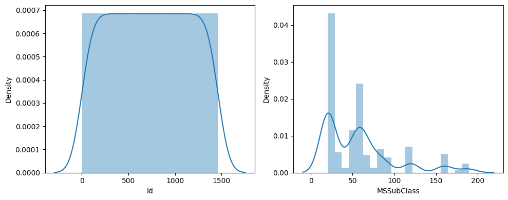

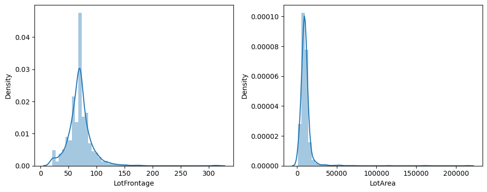

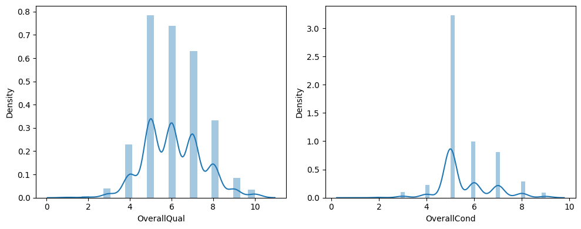

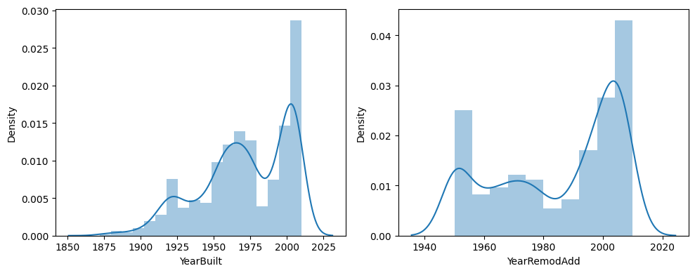

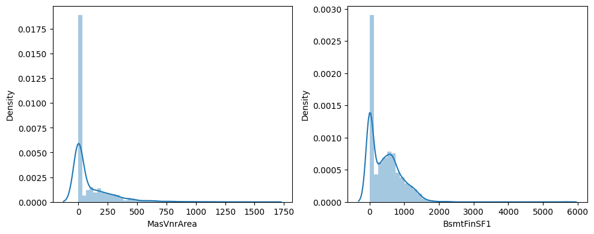

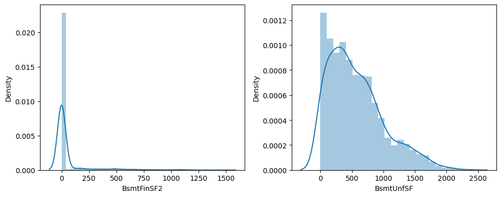

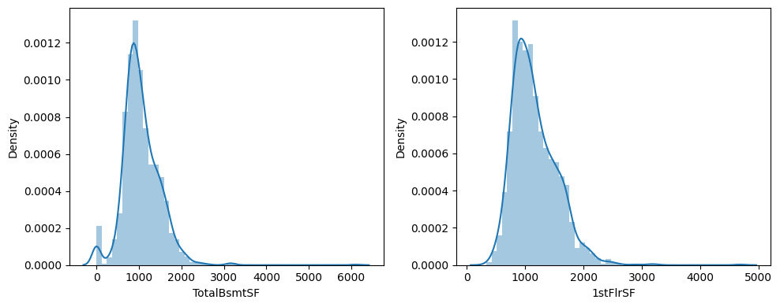

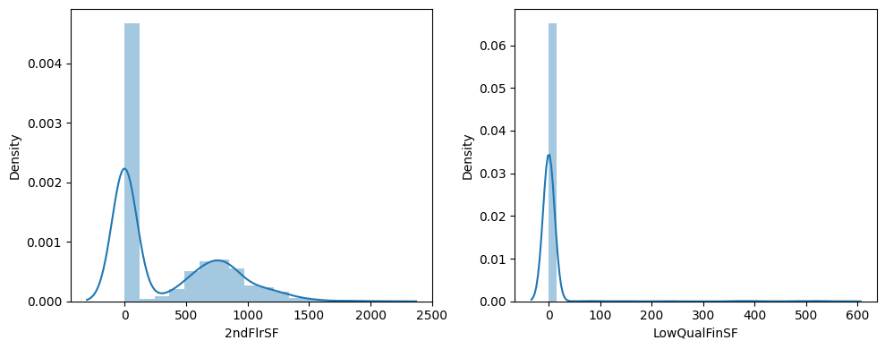

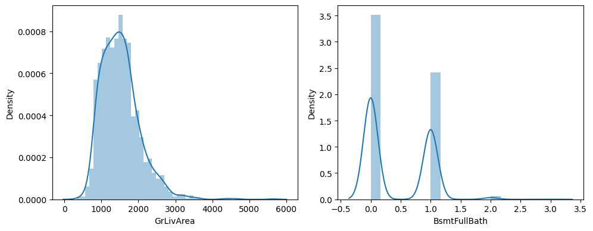

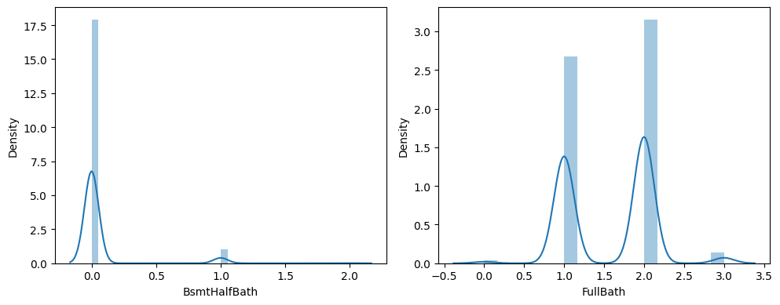

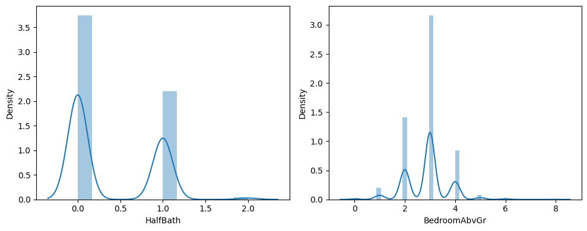

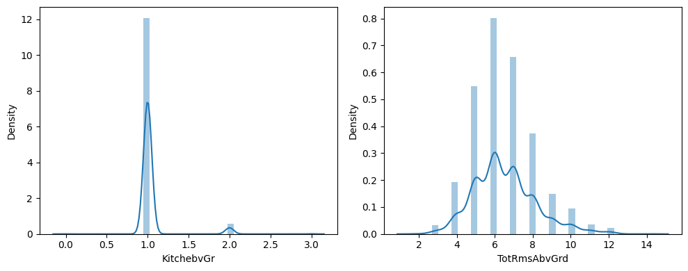

[7 more figures not shown]

```python
# Make historgrams of the data.

#num_cols = ['YearBuilt', 'TotalBsmtSF', 'GrLivArea', 'SalePrice']

num_cols = meanImputedNumDF.columns

for i in range(0, len(num_cols),2):
    plt.figure(figsize=(10,4))
    plt.subplot(121)
    sns.distplot(meanImputedNumDF[num_cols[i]], kde = True)
    plt.subplot(122)
    sns.distplot(meanImputedNumDF[num_cols[i + 1]], kde = True)
    plt.tight_layout()
    plt.show()
```

#### From the above graphs, some columns have values that are clearly too discrete to be of any use for histogram-based analyses. Also, some of the graphs have too many data points placed into one bin on the x-axis. Judging by the shape of the graphs, only the following columns are useful for our purposes.

##### There are the useful columns. All other columns have values that are too discrete or they have too many data points placed into one bin on the x-axis. These columns have graphs with clear humps and obvious skewness.

These are the left-skewed columns:

YearBuilt, GarageYrBlt

These are the right-skewed columns:

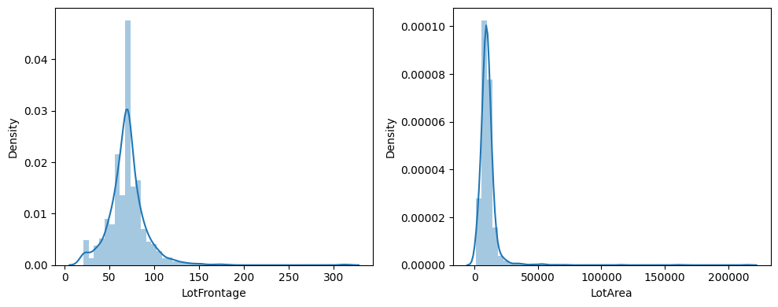

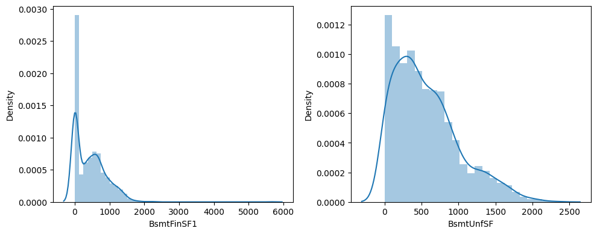

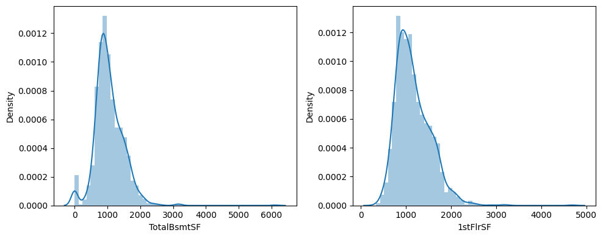

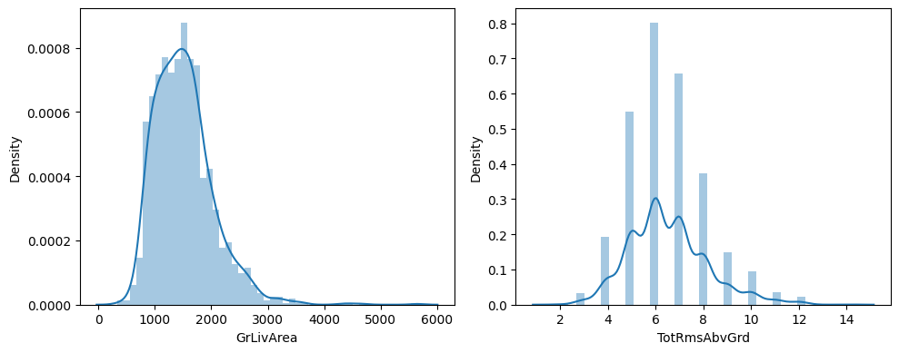

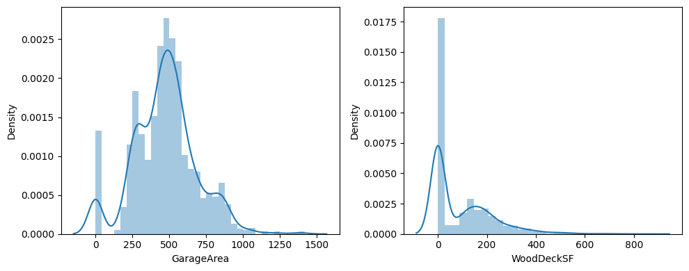

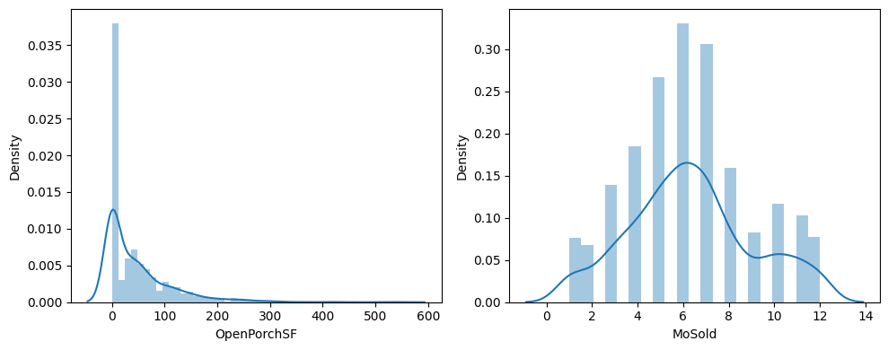

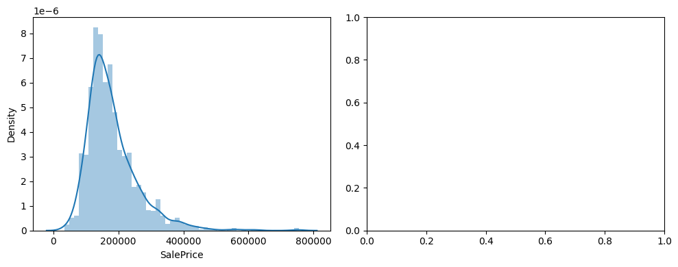

```python
# Plot the useful histograms again.

num_cols = ['LotFrontage', 'LotArea', 'BsmtFinSF1', 'BsmtUnfSF', 'TotalBsmtSF', '1stFlrSF', 'GrLivArea', 'TotRmsAbvGrd', 'GarageArea', 'WoodDeckSF', 'OpenPorchSF', 'MoSold',
            'SalePrice']

for i in range(0, len(num_cols), 2):
    plt.figure(figsize=(10,4))
    plt.subplot(121)
    sns.distplot(meanImputedNumDF[num_cols[i]], kde = True)
    plt.subplot(122)
    if(i + 1 < len(num_cols)):
        sns.distplot(meanImputedNumDF[num_cols[i + 1]], kde = True)
    plt.tight_layout()
    plt.show()
```

### Numerical Data Correlation Matrix

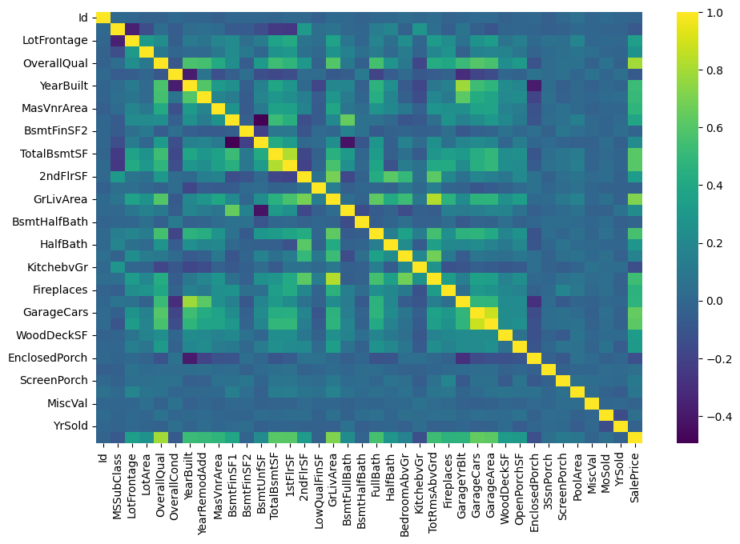

```python
# Plot the correlation matrix of the numerical columns. We will continue using the mean-imputed DataFrame.

plt.figure(figsize=(11,7))
sns.heatmap(meanImputedNumDF.corr(), cmap='viridis')
```

#### There are far too many columns in that matrix. Analyzing it would take too long as it currently is. Only take the 10 most correlated to isolate the most important ones.

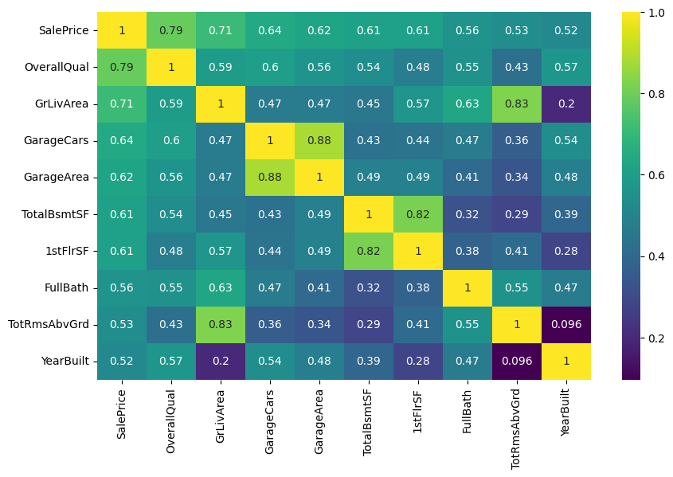

```python
k = 10                                                                      # Select k = 10 as out number of variables for the heatmap
cols = meanImputedNumDF.corr().nlargest(k, 'SalePrice')['SalePrice'].index
cm = meanImputedNumDF[cols].corr()
plt.figure(figsize=(10,6))
sns.heatmap(cm, annot=True, cmap = 'viridis')
```

The correlation values for SalePrice are located in the top row and the leftmost column. Having high correlation values in that row/column is good. However, we may encounter some instances of two variables being highly correlated with each other rather than the SalePrice. This is undesirable since that means we have variables that are redundant for our analysis. If two variables are highly correlated with each other, any analysis performed on one will yield very similar results to an analysis performed on the other.

We must identify and remove redundant variables. If we define two variables that have a correlation of at least 0.8 as being redundant, then we can say the following variables are redundant.

TotRmsAbvGrd and GrLivArea have 0.83 correlation.

```
TotRmsAbvGrd is the total number of rooms above ground that are not bathrooms.
GrLivArea is the total above ground living area in square feet.

This correlation is expected. After all, the more above ground living space you have, the more rooms you can put above the ground.
```

GarageArea and GarageCars have 0.88 correlation.

```
GarageArea is the size of the garage in square feet
GarageCars is the size of the garage in car capacity

Both variables are concerned with the size of the garage. The way the garage size is measured is different for each variable, but they are both measuring the same part of the home.
```

1stFlrSF and TotalBsmtSF have 0.82 correlation.

```
1StFlrSF is the size of the first floor in square feet.
TotalBsmtSF is the area of the basement in square feet.

The basement is located right underneath the first floor. Naturally, the size of the basement is largely constrained by how large the first floor is allowed to be. There is some leeway to make the basement bigger than the first floor since it is located underground, but the first floor’s size is significant confinement metric.
```

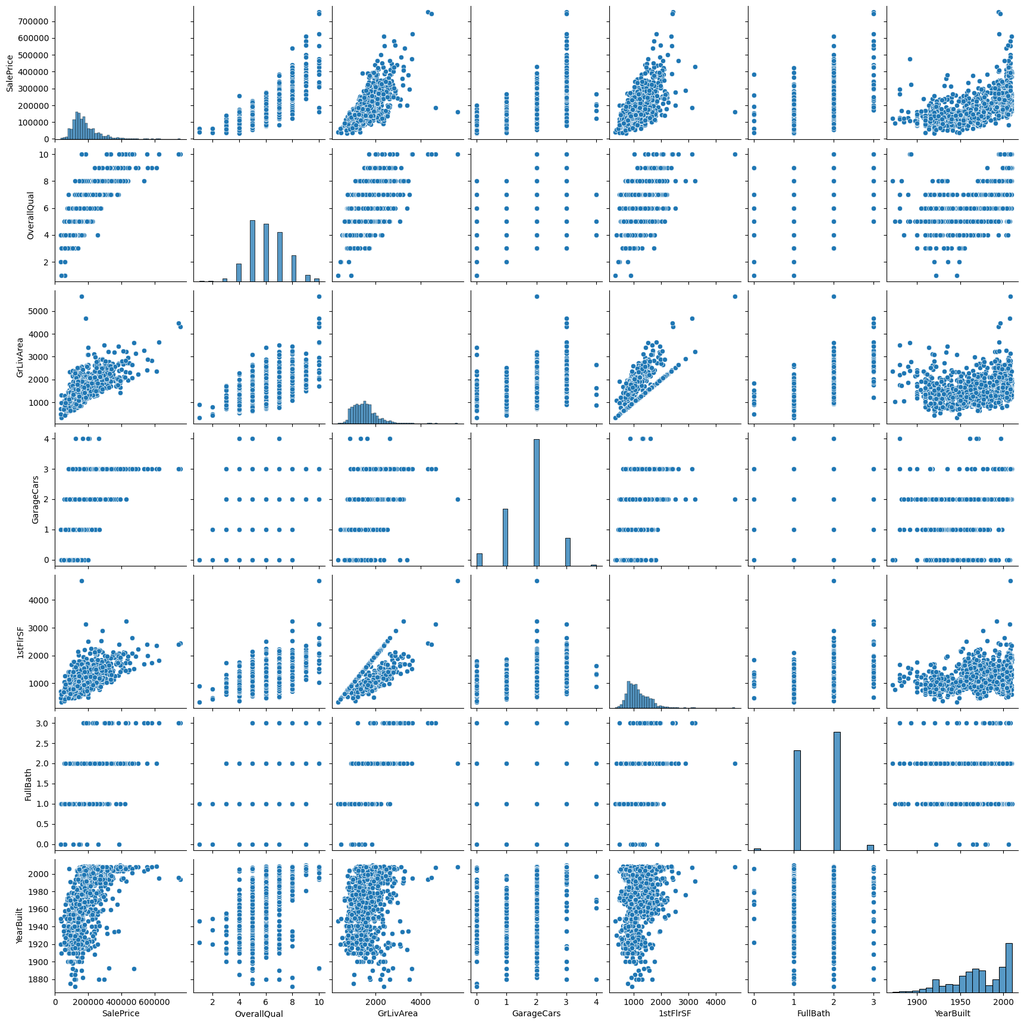

```python
# Visualizing relations between all major variables
cols = ['SalePrice', 'OverallQual', 'GrLivArea', 'GarageCars', '1stFlrSF', 'FullBath', 'YearBuilt']
sns.pairplot(meanImputedNumDF[cols])
```

## Analyze the categorical data

```python
catTrans = categoricDF.T
catTrans
```

|  | 0 | 1 | 2 | 3 | 4 | 5 | 6 | 7 | 8 | 9 | ... | 1450 | 1451 | 1452 | 1453 | 1454 | 1455 | 1456 | 1457 | 1458 | 1459 |
| --- | --- | --- | --- | --- | --- | --- | --- | --- | --- | --- | --- | --- | --- | --- | --- | --- | --- | --- | --- | --- | --- |
| MSZoning | RL | RL | RL | RL | RL | RL | RL | RL | RM | RL | ... | RL | RL | RM | RL | FV | RL | RL | RL | RL | RL |
| Street | Pave | Pave | Pave | Pave | Pave | Pave | Pave | Pave | Pave | Pave | ... | Pave | Pave | Pave | Pave | Pave | Pave | Pave | Pave | Pave | Pave |
| Alley | NaN | NaN | NaN | NaN | NaN | NaN | NaN | NaN | NaN | NaN | ... | NaN | NaN | NaN | NaN | Pave | NaN | NaN | NaN | NaN | NaN |
| LotShape | Reg | Reg | IR1 | IR1 | IR1 | IR1 | Reg | IR1 | Reg | Reg | ... | Reg | Reg | Reg | Reg | Reg | Reg | Reg | Reg | Reg | Reg |
| LandContour | Lvl | Lvl | Lvl | Lvl | Lvl | Lvl | Lvl | Lvl | Lvl | Lvl | ... | Lvl | Lvl | Lvl | Lvl | Lvl | Lvl | Lvl | Lvl | Lvl | Lvl |
| Utilities | AllPub | AllPub | AllPub | AllPub | AllPub | AllPub | AllPub | AllPub | AllPub | AllPub | ... | AllPub | AllPub | AllPub | AllPub | AllPub | AllPub | AllPub | AllPub | AllPub | AllPub |
| LotConfig | Inside | FR2 | Inside | Corner | FR2 | Inside | Inside | Corner | Inside | Corner | ... | FR2 | Inside | Inside | Inside | Inside | Inside | Inside | Inside | Inside | Inside |
| LandSlope | Gtl | Gtl | Gtl | Gtl | Gtl | Gtl | Gtl | Gtl | Gtl | Gtl | ... | Gtl | Gtl | Gtl | Gtl | Gtl | Gtl | Gtl | Gtl | Gtl | Gtl |
| Neighborhood | CollgCr | Veenker | CollgCr | Crawfor | NoRidge | Mitchel | Somerst | NWAmes | OldTown | BrkSide | ... | mes | Somerst | Edwards | Mitchel | Somerst | Gilbert | NWAmes | Crawfor | mes | Edwards |
| Condition1 | Norm | Feedr | Norm | Norm | Norm | Norm | Norm | PosN | Artery | Artery | ... | Norm | Norm | Norm | Norm | Norm | Norm | Norm | Norm | Norm | Norm |
| Condition2 | Norm | Norm | Norm | Norm | Norm | Norm | Norm | Norm | Norm | Artery | ... | Norm | Norm | Norm | Norm | Norm | Norm | Norm | Norm | Norm | Norm |
| BldgType | 1Fam | 1Fam | 1Fam | 1Fam | 1Fam | 1Fam | 1Fam | 1Fam | 1Fam | 2fmCon | ... | Duplex | 1Fam | TwnhsE | 1Fam | 1Fam | 1Fam | 1Fam | 1Fam | 1Fam | 1Fam |
| HouseStyle | 2Story | 1Story | 2Story | 2Story | 2Story | 1.5Fin | 1Story | 2Story | 1.5Fin | 1.5Unf | ... | 2Story | 1Story | SLvl | 1Story | 1Story | 2Story | 1Story | 2Story | 1Story | 1Story |
| RoofStyle | Gable | Gable | Gable | Gable | Gable | Gable | Gable | Gable | Gable | Gable | ... | Gable | Gable | Gable | Gable | Gable | Gable | Gable | Gable | Hip | Gable |
| RoofMatl | CompShg | CompShg | CompShg | CompShg | CompShg | CompShg | CompShg | CompShg | CompShg | CompShg | ... | CompShg | CompShg | CompShg | CompShg | CompShg | CompShg | CompShg | CompShg | CompShg | CompShg |
| Exterior1st | VinylSd | MetalSd | VinylSd | Wd Sdng | VinylSd | VinylSd | VinylSd | HdBoard | BrkFace | MetalSd | ... | VinylSd | CemntBd | VinylSd | VinylSd | VinylSd | VinylSd | Plywood | CemntBd | MetalSd | HdBoard |
| Exterior2nd | VinylSd | MetalSd | VinylSd | Wd Shng | VinylSd | VinylSd | VinylSd | HdBoard | Wd Shng | MetalSd | ... | VinylSd | CmentBd | VinylSd | VinylSd | VinylSd | VinylSd | Plywood | CmentBd | MetalSd | HdBoard |
| MasVnrType | BrkFace | None | BrkFace | None | BrkFace | None | Stone | Stone | None | None | ... | None | Stone | BrkFace | None | None | None | Stone | None | None | None |
| ExterQual | Gd | TA | Gd | TA | Gd | TA | Gd | TA | TA | TA | ... | TA | Gd | TA | TA | Gd | TA | TA | Ex | TA | Gd |
| ExterCond | TA | TA | TA | TA | TA | TA | TA | TA | TA | TA | ... | TA | TA | TA | TA | TA | TA | TA | Gd | TA | TA |
| Foundation | PConc | CBlock | PConc | BrkTil | PConc | Wood | PConc | CBlock | BrkTil | BrkTil | ... | CBlock | PConc | PConc | PConc | PConc | PConc | CBlock | Stone | CBlock | CBlock |
| BsmtQual | Gd | Gd | Gd | TA | Gd | Gd | Ex | Gd | TA | TA | ... | Gd | Gd | Gd | Gd | Gd | Gd | Gd | TA | TA | TA |
| BsmtCond | TA | TA | TA | Gd | TA | TA | TA | TA | TA | TA | ... | TA | TA | TA | TA | TA | TA | TA | Gd | TA | TA |
| BsmtExposure | No | Gd | Mn | No | Av | No | Av | Mn | No | No | ... | No | No | Gd | No | No | No | No | No | Mn | No |
| BsmtFinType1 | GLQ | ALQ | GLQ | ALQ | GLQ | GLQ | GLQ | ALQ | Unf | GLQ | ... | Unf | Unf | GLQ | Unf | GLQ | Unf | ALQ | GLQ | GLQ | BLQ |
| BsmtFinType2 | Unf | Unf | Unf | Unf | Unf | Unf | Unf | BLQ | Unf | Unf | ... | Unf | Unf | Unf | Unf | Unf | Unf | Rec | Unf | Rec | LwQ |
| Heating | GasA | GasA | GasA | GasA | GasA | GasA | GasA | GasA | GasA | GasA | ... | GasA | GasA | GasA | GasA | GasA | GasA | GasA | GasA | GasA | GasA |
| HeatingQC | Ex | Ex | Ex | Gd | Ex | Ex | Ex | Ex | Gd | Ex | ... | TA | Ex | Gd | Ex | Ex | Ex | TA | Ex | Gd | Gd |
| CentralAir | Y | Y | Y | Y | Y | Y | Y | Y | Y | Y | ... | Y | Y | Y | Y | Y | Y | Y | Y | Y | Y |
| Electrical | SBrkr | SBrkr | SBrkr | SBrkr | SBrkr | SBrkr | SBrkr | SBrkr | FuseF | SBrkr | ... | SBrkr | SBrkr | SBrkr | SBrkr | SBrkr | SBrkr | SBrkr | SBrkr | FuseA | SBrkr |
| KitchenQual | Gd | TA | Gd | Gd | Gd | TA | Gd | TA | TA | TA | ... | TA | Ex | TA | TA | Gd | TA | TA | Gd | Gd | TA |
| Functiol | Typ | Typ | Typ | Typ | Typ | Typ | Typ | Typ | Min1 | Typ | ... | Typ | Typ | Typ | Typ | Typ | Typ | Min1 | Typ | Typ | Typ |
| FireplaceQu | NaN | TA | TA | Gd | TA | NaN | Gd | TA | TA | TA | ... | NaN | Gd | NaN | NaN | NaN | TA | TA | Gd | NaN | NaN |
| GarageType | Attchd | Attchd | Attchd | Detchd | Attchd | Attchd | Attchd | Attchd | Detchd | Attchd | ... | NaN | Attchd | Basment | NaN | Attchd | Attchd | Attchd | Attchd | Attchd | Attchd |
| GarageFinish | RFn | RFn | RFn | Unf | RFn | Unf | RFn | RFn | Unf | RFn | ... | NaN | Fin | Fin | NaN | RFn | RFn | Unf | RFn | Unf | Fin |
| GarageQual | TA | TA | TA | TA | TA | TA | TA | TA | Fa | Gd | ... | NaN | TA | TA | NaN | TA | TA | TA | TA | TA | TA |
| GarageCond | TA | TA | TA | TA | TA | TA | TA | TA | TA | TA | ... | NaN | TA | TA | NaN | TA | TA | TA | TA | TA | TA |
| PavedDrive | Y | Y | Y | Y | Y | Y | Y | Y | Y | Y | ... | Y | Y | Y | Y | Y | Y | Y | Y | Y | Y |
| PoolQC | NaN | NaN | NaN | NaN | NaN | NaN | NaN | NaN | NaN | NaN | ... | NaN | NaN | NaN | NaN | NaN | NaN | NaN | NaN | NaN | NaN |
| Fence | NaN | NaN | NaN | NaN | NaN | MnPrv | NaN | NaN | NaN | NaN | ... | NaN | NaN | NaN | NaN | NaN | NaN | MnPrv | GdPrv | NaN | NaN |
| MiscFeature | NaN | NaN | NaN | NaN | NaN | Shed | NaN | Shed | NaN | NaN | ... | NaN | NaN | NaN | NaN | NaN | NaN | NaN | Shed | NaN | NaN |
| SaleType | WD | WD | WD | WD | WD | WD | WD | WD | WD | WD | ... | WD | New | WD | WD | WD | WD | WD | WD | WD | WD |
| SaleCondition | Normal | Normal | Normal | Abnorml | Normal | Normal | Normal | Normal | Abnorml | Normal | ... | Normal | Partial | Normal | Abnorml | Normal | Normal | Normal | Normal | Normal | Normal |

43 rows × 1460 columns

### Missing value treatment for categorial data

```python
# Let us check if there are any missing values in the categorial data.
# As before, "True" indicates missing values and "False" indicates no missing values.
categoricDF.isna().any()
```

```
MSZoning         False
Street           False
Alley             True
LotShape         False
LandContour      False
Utilities        False
LotConfig        False
LandSlope        False
Neighborhood     False
Condition1       False
Condition2       False
BldgType         False
HouseStyle       False
RoofStyle        False
RoofMatl         False
Exterior1st      False
Exterior2nd      False
MasVnrType        True
ExterQual        False
ExterCond        False
Foundation       False
BsmtQual          True
BsmtCond          True
BsmtExposure      True
BsmtFinType1      True
BsmtFinType2      True
Heating          False
HeatingQC        False
CentralAir       False
Electrical        True
KitchenQual      False
Functiol         False
FireplaceQu       True
GarageType        True
GarageFinish      True
GarageQual        True
GarageCond        True
PavedDrive       False
PoolQC            True
Fence             True
MiscFeature       True
SaleType         False
SaleCondition    False
dtype: bool
```